# tarea T-student

The purpose of an investigation by Morley et al. (A-17) was to evaluate the analgesic effectiveness of a daily dose of oral methadone in patients with chronic neuropathic pain syndromes. The researchers used a visual analogue scale (0-100 mm, higher number indicates higher pain) ratings for maximum pain intensity over the course of the day. Each subject took either 20 mg of methadone or a placebo each day for 5 days. Subjects did not know which treatment they were taking. The following table gives the mean maximum pain intensity scores for the 5 days on methadone and the 5 days on placebo. Do these data provide sufficient evidence, at the .05 level of significance, to indicate that in general the maximum pain intensity is lower on days when methadone is taken?

## importar los datos

```r
library(tidyverse)
datos <- read.csv("EXR_C07_S04_03.csv")
datos
```

| Meth | Plac |
| --- | --- |
| 29.8 | 57.2 |
| 73.0 | 69.8 |
| 98.6 | 98.2 |
| 58.8 | 62.4 |
| 60.6 | 67.2 |
| 57.2 | 70.6 |
| 57.2 | 67.8 |
| 89.2 | 95.6 |
| 97.0 | 98.4 |
| 49.8 | 63.2 |

[output cut: 1 more lines]

```r
treatment  <- factor( c(rep(1,11),rep(2,11)),
                      labels = c("Placebo","Methadone"))
```

## Acomodar los datos

```r
score <- c(datos$Plac,datos$Meth)
datos2 <- data.frame(treatment,score)
datos2
```

| treatment | score |
| --- | --- |
| Placebo | 57.2 |
| Placebo | 69.8 |
| Placebo | 98.2 |
| Placebo | 62.4 |
| Placebo | 67.2 |
| Placebo | 70.6 |
| Placebo | 67.8 |
| Placebo | 95.6 |
| Placebo | 98.4 |
| Placebo | 63.2 |

[output cut: 12 more lines]

## Test de varianza

```r
variance_test <- var.test(datos2$score[datos2$treatment=="Placebo"],datos2$score[datos2$treatment =="Methadone"])
variance_test
```

```
    F test to compare two variances

data:  datos2$score[datos2$treatment == "Placebo"] and datos2$score[datos2$treatment == "Methadone"]
F = 0.4593, num df = 10, denom df = 10, p-value = 0.2358
alternative hypothesis: true ratio of variances is not equal to 1
95 percent confidence interval:
 0.1235744 1.7071242
sample estimates:
ratio of variances
         0.4593005
```

## Gráfico

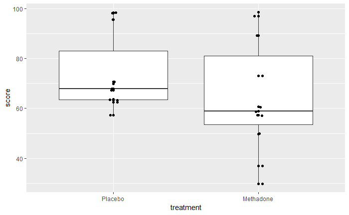

```r
ggplot(data = datos2,
               mapping = aes(x=treatment,y=score))+
                 geom_boxplot()+
                 geom_point()+
                 geom_jitter(height = 0.03,width = 0.03)
```

## Prueba T-student para muestras relacionadas

```r
comparison <- t.test(score~treatment,data = datos2,paired=T)
comparison
```

[output not shown]